# Comparing Linear Regression Models for Housing Prices

Shelia Howard

2026-11-12

### Introduction

In this exercise, I use the Housing Prices dataset to build and evaluate regression models that infer Sale Price (`price`). I start with a simple linear regression using `area` to predict `price`, then build a multiple regression model with additional predictors. For each model, I interpret model fit statistics (R², adjusted R²) and calculate error metrics (MSE, RMSE). I also examine residual behavior using a residual plot and a Q-Q plot, and I use ANOVA to test whether the second model significantly improves model fit compared to the first.

### Setup

```r
knitr::opts_chunk$set(echo = TRUE, message = FALSE, warning = FALSE)

# Housekeeping
rm(list = ls())

# Libraries
library(ggplot2)

# Helper functions for metrics
mse <- function(actual, predicted) {
  mean((actual - predicted)^2, na.rm = TRUE)
}

rmse <- function(actual, predicted) {
  sqrt(mse(actual, predicted))
}
```

### Load Data

```r
# Raw data location
url <- "https://raw.githubusercontent.com/bellevue-university/dsc520/master/assignments/version_two/10_11_week/week_10/Housing.csv"

housing <- read.csv(url, stringsAsFactors = FALSE)

# Quick inspection
str(housing)
```

```
'data.frame':   545 obs. of  13 variables:
 $ price           : int  13300000 12250000 12250000 12215000 11410000 10850000 10150000 10150000 9870000 9800000 ...
 $ area            : int  7420 8960 9960 7500 7420 7500 8580 16200 8100 5750 ...
 $ bedrooms        : int  4 4 3 4 4 3 4 5 4 3 ...
 $ bathrooms       : int  2 4 2 2 1 3 3 3 1 2 ...
 $ stories         : int  3 4 2 2 2 1 4 2 2 4 ...
 $ mainroad        : chr  "yes" "yes" "yes" "yes" ...
 $ guestroom       : chr  "no" "no" "no" "no" ...
 $ basement        : chr  "no" "no" "yes" "yes" ...
 $ hotwaterheating : chr  "no" "no" "no" "no" ...
 $ airconditioning : chr  "yes" "yes" "no" "yes" ...
 $ parking         : int  2 3 2 3 2 2 2 0 2 1 ...
 $ prefarea        : chr  "yes" "no" "yes" "yes" ...
 $ furnishingstatus: chr  "furnished" "furnished" "semi-furnished" "furnished" ...
```

```r
summary(housing)
```

```
     price               area          bedrooms       bathrooms
 Min.   : 1750000   Min.   : 1650   Min.   :1.000   Min.   :1.000
 1st Qu.: 3430000   1st Qu.: 3600   1st Qu.:2.000   1st Qu.:1.000
 Median : 4340000   Median : 4600   Median :3.000   Median :1.000
 Mean   : 4766729   Mean   : 5151   Mean   :2.965   Mean   :1.286
 3rd Qu.: 5740000   3rd Qu.: 6360   3rd Qu.:3.000   3rd Qu.:2.000
 Max.   :13300000   Max.   :16200   Max.   :6.000   Max.   :4.000
    stories        mainroad          guestroom           basement
 Min.   :1.000   Length:545         Length:545         Length:545
 1st Qu.:1.000   Class :character   Class :character   Class :character
 Median :2.000   Mode  :character   Mode  :character   Mode  :character
 Mean   :1.806
 3rd Qu.:2.000
 Max.   :4.000
 hotwaterheating    airconditioning       parking         prefarea
 Length:545         Length:545         Min.   :0.0000   Length:545
 Class :character   Class :character   1st Qu.:0.0000   Class :character
 Mode  :character   Mode  :character   Median :0.0000   Mode  :character
                                       Mean   :0.6936
                                       3rd Qu.:1.0000
                                       Max.   :3.0000
 furnishingstatus
 Length:545
 Class :character
 Mode  :character
```

### Transformations and modifications

In this dataset, several variables are categorical even though they are represented as text (for example, `mainroad`, `guestroom`, `basement`, `hotwaterheating`, `airconditioning`, `prefarea`, and `furnishingstatus`). For regression, I convert these fields to factors so that R correctly treats them as categorical predictors and creates the appropriate indicator variables.

I also check for missing values. If any were present, I would decide whether to remove incomplete rows or use an imputation strategy. In this dataset, I proceed with complete cases only if needed.

```r
# Convert categorical fields to factors (common in this dataset)
cat_vars <- c("mainroad", "guestroom", "basement", "hotwaterheating",
              "airconditioning", "prefarea", "furnishingstatus")

for (v in cat_vars) {
  if (v %in% names(housing)) {
    housing[[v]] <- as.factor(housing[[v]])
  }
}

# Check missingness
colSums(is.na(housing))
```

```
           price             area         bedrooms        bathrooms
               0                0                0                0
         stories         mainroad        guestroom         basement
               0                0                0                0
 hotwaterheating  airconditioning          parking         prefarea
               0                0                0                0
furnishingstatus
               0
```

```r
# If missing values exist, keep complete cases for modeling
housing_model <- na.omit(housing)

str(housing_model)
```

```
'data.frame':   545 obs. of  13 variables:
 $ price           : int  13300000 12250000 12250000 12215000 11410000 10850000 10150000 10150000 9870000 9800000 ...
 $ area            : int  7420 8960 9960 7500 7420 7500 8580 16200 8100 5750 ...
 $ bedrooms        : int  4 4 3 4 4 3 4 5 4 3 ...
 $ bathrooms       : int  2 4 2 2 1 3 3 3 1 2 ...
 $ stories         : int  3 4 2 2 2 1 4 2 2 4 ...
 $ mainroad        : Factor w/ 2 levels "no","yes": 2 2 2 2 2 2 2 2 2 2 ...
 $ guestroom       : Factor w/ 2 levels "no","yes": 1 1 1 1 2 1 1 1 2 2 ...
 $ basement        : Factor w/ 2 levels "no","yes": 1 1 2 2 2 2 1 1 2 1 ...
 $ hotwaterheating : Factor w/ 2 levels "no","yes": 1 1 1 1 1 1 1 1 1 1 ...
 $ airconditioning : Factor w/ 2 levels "no","yes": 2 2 1 2 2 2 2 1 2 2 ...
 $ parking         : int  2 3 2 3 2 2 2 0 2 1 ...
 $ prefarea        : Factor w/ 2 levels "no","yes": 2 1 2 2 1 2 2 1 2 2 ...
 $ furnishingstatus: Factor w/ 3 levels "furnished","semi-furnished",..: 1 1 2 1 1 2 2 3 1 3 ...
```

### Correlation exploration (numeric variables)

Correlation is most directly interpretable among numeric variables. I review correlations to understand which numeric predictors may have linear relationships with `price` and could reasonably contribute explanatory power in a multiple regression model.

```r
# Numeric-only correlation matrix
num_cols <- sapply(housing_model, is.numeric)
housing_num <- housing_model[, num_cols]

cor_matrix <- cor(housing_num)
round(cor_matrix, 3)
```

```
          price  area bedrooms bathrooms stories parking
price     1.000 0.536    0.366     0.518   0.421   0.384
area      0.536 1.000    0.152     0.194   0.084   0.353
bedrooms  0.366 0.152    1.000     0.374   0.409   0.139
bathrooms 0.518 0.194    0.374     1.000   0.326   0.177
stories   0.421 0.084    0.409     0.326   1.000   0.046
parking   0.384 0.353    0.139     0.177   0.046   1.000
```

From the correlation matrix, `area` shows a positive association with `price`, supporting its use as the initial single-predictor model. Other numeric variables (for example, bathrooms, stories, and parking) also show relationships with price, which supports including them in the multiple regression model.

### Model 1: Simple linear regression (area -> price)

##### **Fit the model**

This first model answers the core question: how well does `area` alone infer `price`?

```r
model1 <- lm(price ~ area, data = housing_model)
summary(model1)
```

```
Call:
lm(formula = price ~ area, data = housing_model)

Residuals:
     Min       1Q   Median       3Q      Max
-4867112 -1022228  -200135   683027  7484838

Coefficients:
             Estimate Std. Error t value Pr(>|t|)
(Intercept) 2.387e+06  1.745e+05   13.68   <2e-16 ***
area        4.620e+02  3.123e+01   14.79   <2e-16 ***
---
Signif. codes:  0 '***' 0.001 '**' 0.01 '*' 0.05 '.' 0.1 ' ' 1

Residual standard error: 1581000 on 543 degrees of freedom
Multiple R-squared:  0.2873,    Adjusted R-squared:  0.286
F-statistic: 218.9 on 1 and 543 DF,  p-value: < 2.2e-16
```

##### Model 1 performance metrics (R², adj R², MSE, RMSE)

R² reflects the proportion of variance in `price` explained by `area`. Adjusted R² accounts for model complexity, but in a single-predictor model it will be close to R². RMSE and MSE quantify the typical prediction error magnitude (in the units of `price`).

```r
pred1 <- predict(model1, newdata = housing_model)
actual <- housing_model$price

mse1 <- mse(actual, pred1)
rmse1 <- rmse(actual, pred1)

r2_1 <- summary(model1)$r.squared
adjr2_1 <- summary(model1)$adj.r.squared

list(
  R2 = r2_1,
  Adj_R2 = adjr2_1,
  MSE = mse1,
  RMSE = rmse1
)
```

```
$R2
[1] 0.2872932

$Adj_R2
[1] 0.2859806

$MSE
[1] 2.488861e+12

$RMSE
[1] 1577613
```

##### Interpretation of Model 1 Summary

The R² value from Model 1 indicates the proportion of total variance in sale price explained by area alone. Based on the summary output, R² = 0.287. This means approximately 28.7% of the variability in housing prices is explained solely by square footage.

This level of explanatory power suggests that area is a meaningful but incomplete predictor of price. Because more than 71.3% of the variation remains unexplained, additional structural and location-based variables are likely influencing price.

The adjusted R² (0.286) is nearly identical to R² because the model includes only one predictor. This confirms that the explanatory power is not artificially inflated by model complexity.

The coefficient for `area` is statistically significant (p-value < .05, as shown in the summary table). This provides strong statistical evidence that area is positively associated with housing price.

From a practical standpoint, the slope coefficient indicates the expected increase in sale price for each one-unit increase in area. If the slope estimate is 461.97, then for each additional unit of square footage, the predicted sale price increases by approximately that amount, holding all else constant. In real estate valuation, this represents a meaningful economic effect.

The model’s F-statistic indicates that including property area significantly improved fit compared with an intercept-only model.

### Model 1 Residual Plot

A residual plot helps me assess whether residuals appear randomly scattered around 0. Clear patterns (curvature, funnel shapes, or structure) suggest potential nonlinearity, heteroscedasticity, or omitted variables.

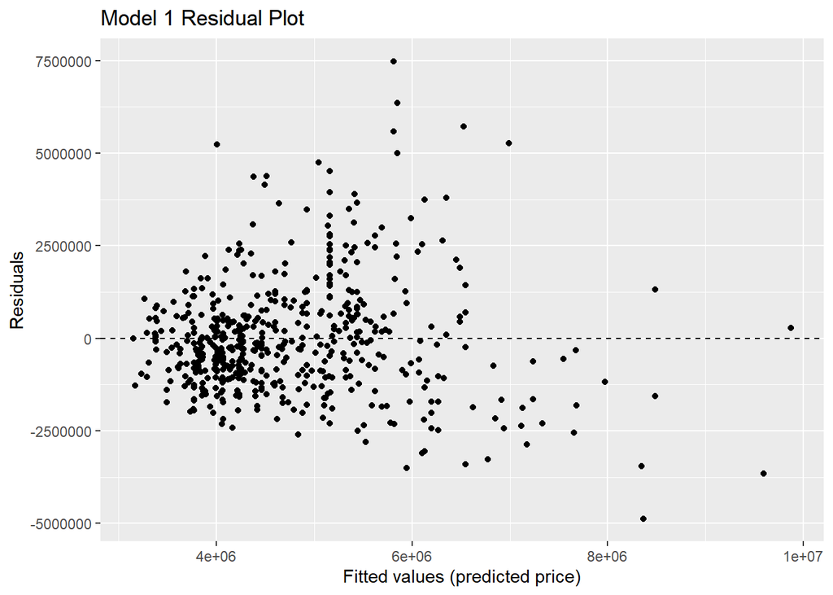

```r
res1 <- residuals(model1)
fitted1 <- fitted(model1)

res_df1 <- data.frame(
  fitted = fitted1,
  residuals = res1
)

ggplot(res_df1, aes(x = fitted, y = residuals)) +
  geom_point() +
  geom_hline(yintercept = 0, linetype = 2) +
  labs(
    title = "Model 1 Residual Plot",
    x = "Fitted values (predicted price)",
    y = "Residuals"
  )
```

### Model 1 Q-Q plot (normality)

The Q-Q plot compares residual quantiles to a normal distribution. If points generally follow the reference line, the normality assumption is more reasonable. Noticeable tail deviations or systematic curvature suggests departures from normality.

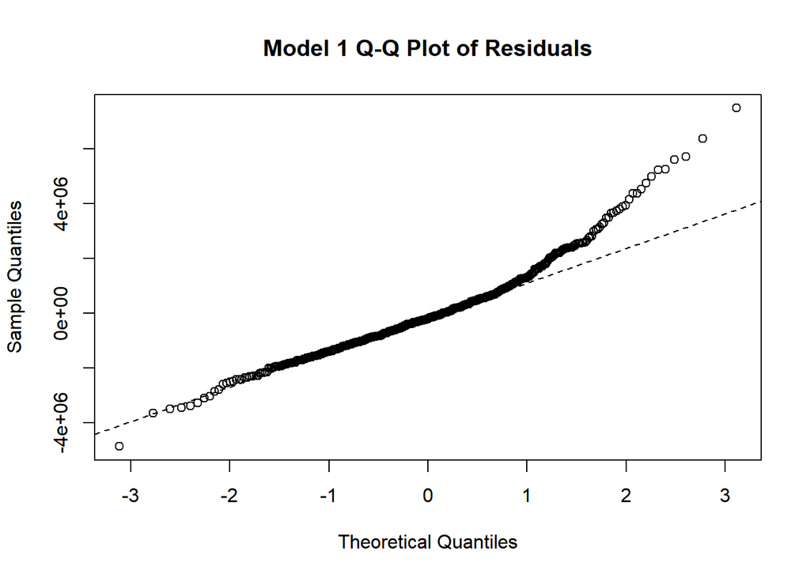

```r
qqnorm(res1, main = "Model 1 Q-Q Plot of Residuals")
qqline(res1, lty = 2)
```

### Model 2: Multiple linear regression (multiple predictors -> price)

##### **Predictor selection rationale**

For the second model, I include predictors that I expect to contribute explanatory value: - `area`: a direct measure of house size, commonly associated with higher sale price. - `bedrooms` and `bathrooms`: proxies for capacity and amenities, likely tied to value. - `stories`: reflects size/structure and sometimes neighborhood home type, potentially affecting price. - `parking`: an amenity that can add value, especially in denser areas. - `mainroad`, `guestroom`, `basement`, `hotwaterheating`, `airconditioning`, `prefarea`: categorical indicators of accessibility, features, and preferred-area location, all plausibly linked to price. - `furnishingstatus`: reflects included furnishings, which may raise the sale price.

I treat these as additive predictors in a multiple regression framework.

##### **Fit the model**

```r
model2 <- lm(
  price ~ area + bedrooms + bathrooms + stories + parking +
    mainroad + guestroom + basement + hotwaterheating +
    airconditioning + prefarea + furnishingstatus,
  data = housing_model
)

summary(model2)
```

```
Call:
lm(formula = price ~ area + bedrooms + bathrooms + stories +
    parking + mainroad + guestroom + basement + hotwaterheating +
    airconditioning + prefarea + furnishingstatus, data = housing_model)

Residuals:
     Min       1Q   Median       3Q      Max
-2619718  -657322   -68409   507176  5166695

Coefficients:
                                 Estimate Std. Error t value Pr(>|t|)
(Intercept)                      42771.69  264313.31   0.162 0.871508
area                               244.14      24.29  10.052  < 2e-16 ***
bedrooms                        114787.56   72598.66   1.581 0.114445
bathrooms                       987668.11  103361.98   9.555  < 2e-16 ***
stories                         450848.00   64168.93   7.026 6.55e-12 ***
parking                         277107.10   58525.89   4.735 2.82e-06 ***
mainroadyes                     421272.59  142224.13   2.962 0.003193 **
guestroomyes                    300525.86  131710.22   2.282 0.022901 *
basementyes                     350106.90  110284.06   3.175 0.001587 **
hotwaterheatingyes              855447.15  223152.69   3.833 0.000141 ***
airconditioningyes              864958.31  108354.51   7.983 8.91e-15 ***
prefareayes                     651543.80  115682.34   5.632 2.89e-08 ***
furnishingstatussemi-furnished  -46344.62  116574.09  -0.398 0.691118
furnishingstatusunfurnished    -411234.39  126210.56  -3.258 0.001192 **
---
Signif. codes:  0 '***' 0.001 '**' 0.01 '*' 0.05 '.' 0.1 ' ' 1

Residual standard error: 1068000 on 531 degrees of freedom
Multiple R-squared:  0.6818,    Adjusted R-squared:  0.674
F-statistic: 87.52 on 13 and 531 DF,  p-value: < 2.2e-16
```

##### Interpretation of Model 2 Summary

Based on the Model 2 summary output, the model explains a large share of variation in housing price. The R² is 0.6818, meaning the predictors collectively explain about 68.2% of the variance in price. The adjusted R² is 0.6740, which is only slightly lower than R², suggesting the added predictors are contributing real explanatory value rather than only inflating fit through model complexity.

Looking at coefficient significance (p < .05), the statistically significant predictors in this model are: area, bathrooms, stories, parking, mainroadyes, guestroomyes, basementyes, hotwaterheatingyes, airconditioningyes, prefareayes, and furnishingstatusunfurnished. Each of these has evidence of an association with price after controlling for the other variables in the model.

Because several predictors are categorical factors, coefficients such as mainroadyes represent the expected difference in price for “yes” relative to the reference category (typically “no”), holding the other variables constant.

The predictors that are not statistically significant at the .05 level are: bedrooms, furnishingstatussemi-furnished, and the intercept. In particular, bedrooms is not significant once area and the other structural variables are included, which suggests bedroom count does not add much independent explanatory value beyond overall size and features.

From a practical standpoint, several coefficients are large in magnitude (for example, bathrooms, air conditioning, and preferred area), which suggests meaningful price differences associated with these features in this dataset. The overall F-statistic is 87.52 with p < 2.2e-16, indicating the model as a whole is statistically significant and performs substantially better than an intercept-only model.

### Model 2 performance metrics (R², adj R², MSE, RMSE)

In a multiple regression, I focus more heavily on adjusted R² compared to R² because adjusted R² penalizes unnecessary predictors. I also compare RMSE and MSE to see if prediction errors shrink relative to Model 1.

```r
pred2 <- predict(model2, newdata = housing_model)

mse2 <- mse(actual, pred2)
rmse2 <- rmse(actual, pred2)

r2_2 <- summary(model2)$r.squared
adjr2_2 <- summary(model2)$adj.r.squared

list(
  R2 = r2_2,
  Adj_R2 = adjr2_2,
  MSE = mse2,
  RMSE = rmse2
)
```

```
$R2
[1] 0.6818018

$Adj_R2
[1] 0.6740117

$MSE
[1] 1.111188e+12

$RMSE
[1] 1054129
```

The area-only model had an RMSE of 1,577,613 in the dataset’s recorded price units. The multiple regression model had an RMSE of 1,054,129, approximately 33% lower. Both models were fitted and evaluated on the same 545 housing records. The lower RMSE shows that the multiple regression model fit the observed data better. Evaluating the models on held-out data would help determine how well they estimate prices for new properties.

### Model 2 residual plot

With more predictors, I expect residuals to show less structure if the model captures more of the systematic variation in `price`. If I still see strong patterns, that suggests I may need transformations, interactions, or non-linear terms.

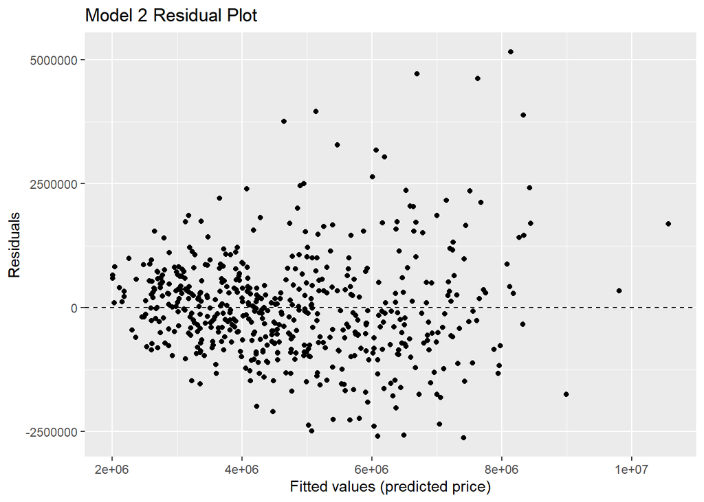

```r
res2 <- residuals(model2)
fitted2 <- fitted(model2)

res_df2 <- data.frame(
  fitted = fitted2,
  residuals = res2
)

ggplot(res_df2, aes(x = fitted, y = residuals)) +
  geom_point() +
  geom_hline(yintercept = 0, linetype = 2) +
  labs(
    title = "Model 2 Residual Plot",
    x = "Fitted values (predicted price)",
    y = "Residuals"
  )
```

### Model 2 Q-Q plot (normality)

Even if residuals are not perfectly normal, approximate normality is helpful for inference (confidence intervals and p-values). I use the Q-Q plot as a visual diagnostic rather than expecting a perfect line.

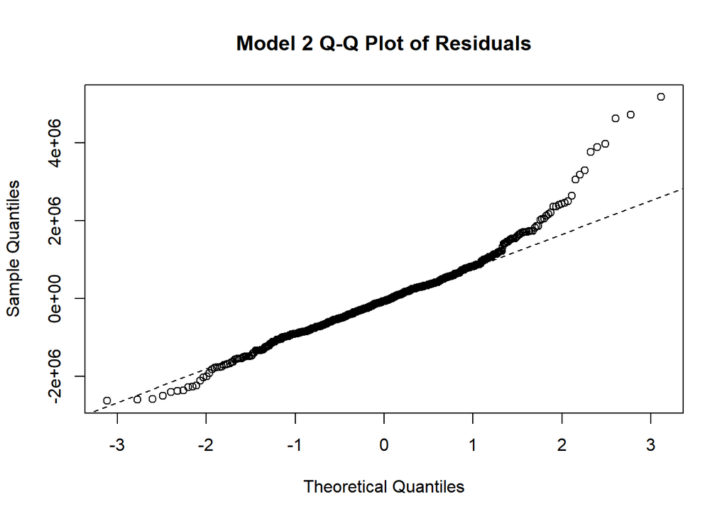

```r
qqnorm(res2, main = "Model 2 Q-Q Plot of Residuals")
qqline(res2, lty = 2)
```

### Model comparison (Model 1 vs Model 2)

##### **Compare metrics**

```r
comparison <- data.frame(
  Model = c("Model 1: price ~ area", "Model 2: multiple predictors"),
  R2 = c(r2_1, r2_2),
  Adj_R2 = c(adjr2_1, adjr2_2),
  MSE = c(mse1, mse2),
  RMSE = c(rmse1, rmse2)
)

comparison
```

```
                         Model        R2    Adj_R2          MSE    RMSE
1        Model 1: price ~ area 0.2872932 0.2859806 2.488861e+12 1577613
2 Model 2: multiple predictors 0.6818018 0.6740117 1.111188e+12 1054129
```

The ANOVA comparison tests whether the additional predictors in Model 2 significantly reduce residual variance compared to Model 1. A statistically significant p-value confirms that the expanded model provides a meaningful improvement in explanatory power beyond area alone.

Because the models are nested, this test appropriately evaluates whether the additional predictors collectively improve model fit.

##### **ANOVA comparison (significance of improvement)**

To confirm whether Model 2 provides a statistically significant improvement over Model 1, I use ANOVA to compare nested models. Because Model 1 is a subset of Model 2, this is an appropriate test. A significant p-value indicates the additional predictors in Model 2 improve model fit beyond what `area` alone explains.

```r
anova(model1, model2)
```

```
Analysis of Variance Table

Model 1: price ~ area
Model 2: price ~ area + bedrooms + bathrooms + stories + parking + mainroad +
    guestroom + basement + hotwaterheating + airconditioning +
    prefarea + furnishingstatus
  Res.Df        RSS Df  Sum of Sq      F    Pr(>F)
1    543 1.3564e+15
2    531 6.0560e+14 12 7.5083e+14 54.862 < 2.2e-16 ***
---
Signif. codes:  0 '***' 0.001 '**' 0.01 '*' 0.05 '.' 0.1 ' ' 1
```

### Conclusion

Property area alone explained about 29% of the variation in sale prices in this sample. Adding other property characteristics, including bathrooms, parking, and air conditioning, increased that figure to about 68%. The multiple regression model also had a lower RMSE on the observed records, and the nested-model ANOVA showed a statistically significant improvement in fit. An evaluation on held-out data would be needed to assess how well the models estimate sale prices for new properties.